# Telecom Churn Case Study - Part 2

**This notebook contains**

- Test Train Split
- Class Imbalance
- Standardization
- Modelling
  - Model 1 : Logistic Regression with RFE & Manual Elimination ( Interpretable Model )
  - Model 2 : PCA + Logistic Regression
  - Model 3 : PCA + Random Forest Classifier
  - Model 4 : PCA + XGBoost

**For the previous steps, refer to Part-1**

```python
import numpy as np
import pandas as pd
import matplotlib.pyplot as plt
import seaborn as sns
# import tabulate
import warnings
pd.set_option('display.max_columns', None)
pd.set_option('display.max_rows', None)
warnings.filterwarnings('ignore')
```

```python
data = pd.read_csv('cleaned_churn_data.csv', index_col='mobile_number')
data.drop(columns=['Unnamed: 0'], inplace=True)
data.head()
```

| mobile_number | onnet_mou_6 | onnet_mou_7 | onnet_mou_8 | offnet_mou_6 | offnet_mou_7 | offnet_mou_8 | roam_ic_mou_6 | roam_ic_mou_7 | roam_ic_mou_8 | roam_og_mou_6 | roam_og_mou_7 | roam_og_mou_8 | loc_og_t2t_mou_6 | loc_og_t2t_mou_7 | loc_og_t2t_mou_8 | loc_og_t2m_mou_6 | loc_og_t2m_mou_7 | loc_og_t2m_mou_8 | loc_og_t2f_mou_6 | loc_og_t2f_mou_7 | loc_og_t2f_mou_8 | loc_og_t2c_mou_6 | loc_og_t2c_mou_7 | loc_og_t2c_mou_8 | loc_og_mou_6 | loc_og_mou_7 | loc_og_mou_8 | std_og_t2t_mou_6 | std_og_t2t_mou_7 | … |
| --- | --- | --- | --- | --- | --- | --- | --- | --- | --- | --- | --- | --- | --- | --- | --- | --- | --- | --- | --- | --- | --- | --- | --- | --- | --- | --- | --- | --- | --- | --- |
| 7000701601 | 57.84 | 54.68 | 52.29 | 453.43 | 567.16 | 325.91 | 16.23 | 33.49 | 31.64 | 23.74 | 12.59 | 38.06 | 51.39 | 31.38 | 40.28 | 308.63 | 447.38 | 162.28 | 62.13 | 55.14 | 53.23 | 0.0 | 0.0 | 0.00 | 422.16 | 533.91 | 255.79 | 4.30 | 23.29 | … |
| 7001524846 | 413.69 | 351.03 | 35.08 | 94.66 | 80.63 | 136.48 | 0.00 | 0.00 | 0.00 | 0.00 | 0.00 | 0.00 | 297.13 | 217.59 | 12.49 | 80.96 | 70.58 | 50.54 | 0.00 | 0.00 | 0.00 | 0.0 | 0.0 | 7.15 | 378.09 | 288.18 | 63.04 | 116.56 | 133.43 | … |
| 7002191713 | 501.76 | 108.39 | 534.24 | 413.31 | 119.28 | 482.46 | 23.53 | 144.24 | 72.11 | 7.98 | 35.26 | 1.44 | 49.63 | 6.19 | 36.01 | 151.13 | 47.28 | 294.46 | 4.54 | 0.00 | 23.51 | 0.0 | 0.0 | 0.49 | 205.31 | 53.48 | 353.99 | 446.41 | 85.98 | … |
| 7000875565 | 50.51 | 74.01 | 70.61 | 296.29 | 229.74 | 162.76 | 0.00 | 2.83 | 0.00 | 0.00 | 17.74 | 0.00 | 42.61 | 65.16 | 67.38 | 273.29 | 145.99 | 128.28 | 0.00 | 4.48 | 10.26 | 0.0 | 0.0 | 0.00 | 315.91 | 215.64 | 205.93 | 7.89 | 2.58 | … |
| 7000187447 | 1185.91 | 9.28 | 7.79 | 61.64 | 0.00 | 5.54 | 0.00 | 4.76 | 4.81 | 0.00 | 8.46 | 13.34 | 38.99 | 0.00 | 0.00 | 58.54 | 0.00 | 0.00 | 0.00 | 0.00 | 0.00 | 0.0 | 0.0 | 0.00 | 97.54 | 0.00 | 0.00 | 1146.91 | 0.81 | … |

### Train-Test Split

```python
y = data.pop('Churn') # Predicted / Target Variable
X = data # Predictor variables
```

```python
from sklearn.model_selection import train_test_split
X_train, X_test, y_train, y_test = train_test_split(X,y, train_size=0.7, random_state=42)
```

### Class Imbalance

```python
y.value_counts(normalize=True).to_frame()
```

|  | Churn |
| --- | --- |
| 0 | 0.913598 |
| 1 | 0.086402 |

```python
# Ratio of classes
class_0 = y[y == 0].count()
class_1 = y[y == 1].count()

print(f'Class Imbalance Ratio : {round(class_1/class_0,3)}')
```

```
Class Imbalance Ratio : 0.095
```

- To account for class imbalance, Synthetic Minority Class Oversampling Technique (SMOTE) could be used.

### Using SMOTE

```python
#!pip install imblearn
from imblearn.over_sampling import SMOTE
smt = SMOTE(random_state=42, k_neighbors=5)

# Resampling Train set to account for class imbalance

X_train_resampled, y_train_resampled= smt.fit_resample(X_train, y_train)
X_train_resampled.head()
```

|  | onnet_mou_6 | onnet_mou_7 | onnet_mou_8 | offnet_mou_6 | offnet_mou_7 | offnet_mou_8 | roam_ic_mou_6 | roam_ic_mou_7 | roam_ic_mou_8 | roam_og_mou_6 | roam_og_mou_7 | roam_og_mou_8 | loc_og_t2t_mou_6 | loc_og_t2t_mou_7 | loc_og_t2t_mou_8 | loc_og_t2m_mou_6 | loc_og_t2m_mou_7 | loc_og_t2m_mou_8 | loc_og_t2f_mou_6 | loc_og_t2f_mou_7 | loc_og_t2f_mou_8 | loc_og_t2c_mou_6 | loc_og_t2c_mou_7 | loc_og_t2c_mou_8 | loc_og_mou_6 | loc_og_mou_7 | loc_og_mou_8 | std_og_t2t_mou_6 | std_og_t2t_mou_7 | … |
| --- | --- | --- | --- | --- | --- | --- | --- | --- | --- | --- | --- | --- | --- | --- | --- | --- | --- | --- | --- | --- | --- | --- | --- | --- | --- | --- | --- | --- | --- | --- |
| 0 | 53.01 | 52.64 | 37.48 | 316.01 | 195.74 | 68.36 | 0.0 | 0.0 | 0.0 | 0.0 | 0.0 | 0.0 | 53.01 | 52.64 | 37.48 | 282.38 | 171.64 | 44.51 | 31.59 | 17.38 | 19.43 | 0.0 | 0.0 | 0.00 | 366.99 | 241.68 | 101.43 | 0.00 | 0.00 | … |
| 1 | 91.39 | 216.14 | 150.58 | 504.19 | 301.98 | 434.41 | 0.0 | 0.0 | 0.0 | 0.0 | 0.0 | 0.0 | 40.36 | 36.21 | 27.73 | 37.26 | 36.73 | 59.61 | 0.00 | 0.00 | 0.00 | 0.0 | 0.0 | 0.58 | 77.63 | 72.94 | 87.34 | 51.03 | 179.93 | … |
| 2 | 11.96 | 14.13 | 0.40 | 1.51 | 0.00 | 0.00 | 0.0 | 0.0 | 0.0 | 0.0 | 0.0 | 0.0 | 11.96 | 14.13 | 0.40 | 1.51 | 0.00 | 0.00 | 0.00 | 0.00 | 0.00 | 0.0 | 0.0 | 0.00 | 13.48 | 14.13 | 0.40 | 0.00 | 0.00 | … |
| 3 | 532.66 | 537.31 | 738.21 | 49.03 | 71.64 | 39.43 | 0.0 | 0.0 | 0.0 | 0.0 | 0.0 | 0.0 | 24.46 | 19.79 | 37.74 | 41.26 | 47.86 | 39.43 | 1.19 | 4.04 | 0.00 | 0.0 | 0.0 | 0.00 | 66.93 | 71.71 | 77.18 | 508.19 | 517.51 | … |
| 4 | 122.68 | 105.51 | 149.33 | 302.23 | 211.44 | 264.11 | 0.0 | 0.0 | 0.0 | 0.0 | 0.0 | 0.0 | 122.68 | 105.51 | 149.33 | 301.04 | 194.06 | 257.14 | 0.00 | 0.66 | 0.51 | 0.0 | 0.0 | 0.00 | 423.73 | 300.24 | 406.99 | 0.00 | 0.00 | … |

### Standardizing Columns

```python
# columns with numerical data
condition1 = data.dtypes == 'int'
condition2 = data.dtypes == 'float'
numerical_vars = data.columns[condition1 | condition2].to_list()
```

```python
# Standard scaling
from sklearn.preprocessing import StandardScaler
scaler = StandardScaler()

# Fit and transform train set
X_train_resampled[numerical_vars] = scaler.fit_transform(X_train_resampled[numerical_vars])

# Transform test set
X_test[numerical_vars] = scaler.transform(X_test[numerical_vars])
```

```python
# summary statistics of standardized variables
round(X_train_resampled.describe(),2)
```

|  | onnet_mou_6 | onnet_mou_7 | onnet_mou_8 | offnet_mou_6 | offnet_mou_7 | offnet_mou_8 | roam_ic_mou_6 | roam_ic_mou_7 | roam_ic_mou_8 | roam_og_mou_6 | roam_og_mou_7 | roam_og_mou_8 | loc_og_t2t_mou_6 | loc_og_t2t_mou_7 | loc_og_t2t_mou_8 | loc_og_t2m_mou_6 | loc_og_t2m_mou_7 | loc_og_t2m_mou_8 | loc_og_t2f_mou_6 | loc_og_t2f_mou_7 | loc_og_t2f_mou_8 | loc_og_t2c_mou_6 | loc_og_t2c_mou_7 | loc_og_t2c_mou_8 | loc_og_mou_6 | loc_og_mou_7 | loc_og_mou_8 | std_og_t2t_mou_6 | std_og_t2t_mou_7 | … |
| --- | --- | --- | --- | --- | --- | --- | --- | --- | --- | --- | --- | --- | --- | --- | --- | --- | --- | --- | --- | --- | --- | --- | --- | --- | --- | --- | --- | --- | --- | --- |
| count | 38374.00 | 38374.00 | 38374.00 | 38374.00 | 38374.00 | 38374.00 | 38374.00 | 38374.00 | 38374.00 | 38374.00 | 38374.00 | 38374.00 | 38374.00 | 38374.00 | 38374.00 | 38374.00 | 38374.00 | 38374.00 | 38374.00 | 38374.00 | 38374.00 | 38374.00 | 38374.00 | 38374.00 | 38374.00 | 38374.00 | 38374.00 | 38374.00 | 38374.00 | … |
| mean | -0.00 | -0.00 | 0.00 | 0.00 | -0.00 | -0.00 | -0.00 | -0.00 | 0.00 | -0.00 | -0.00 | 0.00 | -0.00 | -0.00 | 0.00 | 0.00 | -0.00 | 0.00 | 0.00 | -0.00 | -0.00 | -0.00 | 0.00 | -0.00 | 0.00 | -0.00 | -0.00 | -0.00 | -0.00 | … |
| std | 1.00 | 1.00 | 1.00 | 1.00 | 1.00 | 1.00 | 1.00 | 1.00 | 1.00 | 1.00 | 1.00 | 1.00 | 1.00 | 1.00 | 1.00 | 1.00 | 1.00 | 1.00 | 1.00 | 1.00 | 1.00 | 1.00 | 1.00 | 1.00 | 1.00 | 1.00 | 1.00 | 1.00 | 1.00 | … |
| min | -0.73 | -0.68 | -0.53 | -0.94 | -0.89 | -0.70 | -0.31 | -0.32 | -0.33 | -0.33 | -0.36 | -0.36 | -0.50 | -0.49 | -0.42 | -0.75 | -0.73 | -0.59 | -0.38 | -0.38 | -0.33 | -0.37 | -0.37 | -0.31 | -0.76 | -0.74 | -0.60 | -0.57 | -0.54 | … |
| 25% | -0.63 | -0.60 | -0.52 | -0.66 | -0.65 | -0.66 | -0.31 | -0.32 | -0.33 | -0.33 | -0.36 | -0.36 | -0.45 | -0.45 | -0.42 | -0.63 | -0.63 | -0.59 | -0.38 | -0.38 | -0.33 | -0.37 | -0.37 | -0.31 | -0.63 | -0.63 | -0.60 | -0.57 | -0.54 | … |
| 50% | -0.42 | -0.41 | -0.40 | -0.33 | -0.33 | -0.36 | -0.31 | -0.32 | -0.33 | -0.33 | -0.36 | -0.36 | -0.32 | -0.32 | -0.35 | -0.37 | -0.37 | -0.43 | -0.38 | -0.38 | -0.33 | -0.37 | -0.37 | -0.31 | -0.36 | -0.37 | -0.43 | -0.50 | -0.48 | … |
| 75% | 0.20 | 0.15 | 0.01 | 0.27 | 0.26 | 0.23 | -0.27 | -0.25 | -0.22 | -0.28 | -0.21 | -0.20 | 0.01 | 0.00 | -0.04 | 0.23 | 0.22 | 0.16 | -0.13 | -0.13 | -0.20 | -0.24 | -0.21 | -0.31 | 0.24 | 0.24 | 0.17 | 0.08 | 0.01 | … |
| max | 4.09 | 4.46 | 5.67 | 4.02 | 4.45 | 5.24 | 6.11 | 6.09 | 6.19 | 5.41 | 5.44 | 5.67 | 7.06 | 7.45 | 7.71 | 5.26 | 5.34 | 5.79 | 7.25 | 7.30 | 7.57 | 6.32 | 6.47 | 7.42 | 5.35 | 5.53 | 5.83 | 4.02 | 4.36 | … |

## Modelling

### Model 1 : Interpretable Model : Logistic Regression

#### Baseline Logistic Regression Model

```python
from sklearn.linear_model import LogisticRegression


baseline_model = LogisticRegression(random_state=100, class_weight='balanced') # `weight of class` balancing technique used
baseline_model = baseline_model.fit(X_train, y_train)

y_train_pred = baseline_model.predict_proba(X_train)[:,1]
y_test_pred  = baseline_model.predict_proba(X_test)[:,1]
```

```python
y_train_pred = pd.Series(y_train_pred,index = X_train.index, ) # converting test and train to a series to preserve index
y_test_pred = pd.Series(y_test_pred,index = X_test.index)
```

**Baseline Performance**

```python
# Function for Baseline Performance Metrics
import math
def model_metrics(matrix) :
    TN = matrix[0][0]
    TP = matrix[1][1]
    FP = matrix[0][1]
    FN = matrix[1][0]
    accuracy = round((TP + TN)/float(TP+TN+FP+FN),3)
    print('Accuracy :' ,accuracy )
    sensitivity = round(TP/float(FN + TP),3)
    print('Sensitivity / True Positive Rate / Recall :', sensitivity)
    specificity = round(TN/float(TN + FP),3)
    print('Specificity / True Negative Rate : ', specificity)
    precision = round(TP/float(TP + FP),3)
    print('Precision / Positive Predictive Value :', precision)
    print('F1-score :', round(2*precision*sensitivity/(precision + sensitivity),3))
```

```python
# Prediction at threshold of 0.5
classification_threshold = 0.5

y_train_pred_classified = y_train_pred.map(lambda x : 1 if x > classification_threshold else 0)
y_test_pred_classified = y_test_pred.map(lambda x : 1 if x > classification_threshold else 0)
```

```python
from sklearn.metrics import confusion_matrix
train_matrix = confusion_matrix(y_train, y_train_pred_classified)
print('Confusion Matrix for train:\n', train_matrix)
test_matrix = confusion_matrix(y_test, y_test_pred_classified)
print('\nConfusion Matrix for test: \n', test_matrix)
```

```
Confusion Matrix for train:
 [[16001  3186]
 [  326  1494]]

Confusion Matrix for test:
 [[6090 2141]
 [ 149  624]]
```

```python
# Baseline Model Performance :

print('Train Performance : \n')
model_metrics(train_matrix)

print('\n\nTest Performance : \n')
model_metrics(test_matrix)
```

```
Train Performance :

Accuracy : 0.833
Sensitivity / True Positive Rate / Recall : 0.821
Specificity / True Negative Rate :  0.834
Precision / Positive Predictive Value : 0.319
F1-score : 0.459


Test Performance :

Accuracy : 0.746
Sensitivity / True Positive Rate / Recall : 0.807
Specificity / True Negative Rate :  0.74
Precision / Positive Predictive Value : 0.226
F1-score : 0.353
```

**Baseline Performance - Finding Optimum Probability Cutoff**

```python
# Specificity / Sensitivity Tradeoff

# Classification at probability thresholds between 0 and 1
y_train_pred_thres = pd.DataFrame(index=X_train.index)
thresholds = [float(x)/10 for x in range(10)]

def thresholder(x, thresh) :
    if x > thresh :
        return 1
    else :
        return 0


for i in thresholds:
    y_train_pred_thres[i]= y_train_pred.map(lambda x : thresholder(x,i))
y_train_pred_thres.head()
```

| mobile_number | 0.0 | 0.1 | 0.2 | 0.3 | 0.4 | 0.5 | 0.6 | 0.7 | 0.8 | 0.9 |
| --- | --- | --- | --- | --- | --- | --- | --- | --- | --- | --- |
| 7000166926 | 1 | 1 | 1 | 1 | 1 | 0 | 0 | 0 | 0 | 0 |
| 7001343085 | 1 | 1 | 1 | 0 | 0 | 0 | 0 | 0 | 0 | 0 |
| 7001863283 | 1 | 1 | 0 | 0 | 0 | 0 | 0 | 0 | 0 | 0 |
| 7002275981 | 1 | 1 | 1 | 0 | 0 | 0 | 0 | 0 | 0 | 0 |
| 7001086221 | 1 | 0 | 0 | 0 | 0 | 0 | 0 | 0 | 0 | 0 |

```python
# # sensitivity, specificity, accuracy for each threshold
metrics_df = pd.DataFrame(columns=['sensitivity', 'specificity', 'accuracy'])

# Function for calculation of metrics for each threshold
def model_metrics_thres(matrix) :
    TN = matrix[0][0]
    TP = matrix[1][1]
    FP = matrix[0][1]
    FN = matrix[1][0]
    accuracy = round((TP + TN)/float(TP+TN+FP+FN),3)
    sensitivity = round(TP/float(FN + TP),3)
    specificity = round(TN/float(TN + FP),3)
    return sensitivity,specificity,accuracy

# generating a data frame for metrics for each threshold
for thres,column in zip(thresholds,y_train_pred_thres.columns.to_list()) :
    confusion = confusion_matrix(y_train, y_train_pred_thres.loc[:,column])
    sensitivity,specificity,accuracy = model_metrics_thres(confusion)

    metrics_df =  metrics_df.append({
        'sensitivity' :sensitivity,
        'specificity' : specificity,
        'accuracy' : accuracy
    }, ignore_index = True)

metrics_df.index = thresholds
metrics_df
```

|  | sensitivity | specificity | accuracy |
| --- | --- | --- | --- |
| 0.0 | 1.000 | 0.000 | 0.087 |
| 0.1 | 0.974 | 0.345 | 0.399 |
| 0.2 | 0.947 | 0.523 | 0.560 |
| 0.3 | 0.910 | 0.658 | 0.680 |
| 0.4 | 0.868 | 0.763 | 0.772 |
| 0.5 | 0.821 | 0.834 | 0.833 |
| 0.6 | 0.770 | 0.883 | 0.873 |
| 0.7 | 0.677 | 0.921 | 0.899 |
| 0.8 | 0.493 | 0.953 | 0.913 |
| 0.9 | 0.234 | 0.981 | 0.916 |

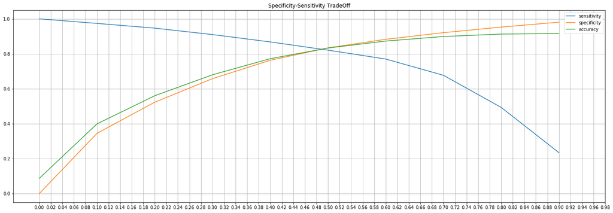

```python
metrics_df.plot(kind='line', figsize=(24,8), grid=True, xticks=np.arange(0,1,0.02),
                title='Specificity-Sensitivity TradeOff');
```

#### Baseline Performance at Optimum Cutoff

```python
optimum_cutoff = 0.49
y_train_pred_final = y_train_pred.map(lambda x : 1 if x > optimum_cutoff else 0)
y_test_pred_final = y_test_pred.map(lambda x : 1 if x > optimum_cutoff else 0)

train_matrix = confusion_matrix(y_train, y_train_pred_final)
print('Confusion Matrix for train:\n', train_matrix)
test_matrix = confusion_matrix(y_test, y_test_pred_final)
print('\nConfusion Matrix for test: \n', test_matrix)
```

[output not shown]

```python
print('Train Performance: \n')
model_metrics(train_matrix)

print('\n\nTest Performance : \n')
model_metrics(test_matrix)
```

[output not shown]

```python
# ROC_AUC score
from sklearn.metrics import roc_auc_score
print('ROC AUC score for Train : ',round(roc_auc_score(y_train, y_train_pred),3), '\n' )
print('ROC AUC score for Test : ',round(roc_auc_score(y_test, y_test_pred),3) )
```

```
ROC AUC score for Train :  0.891

ROC AUC score for Test :  0.838
```

#### Feature Selection using RFE

```python
from sklearn.feature_selection import RFE
from sklearn.linear_model import LogisticRegression
lr = LogisticRegression(random_state=100 , class_weight='balanced')
rfe = RFE(lr, 15)
results = rfe.fit(X_train,y_train)
results.support_
```

```
array([False, False, False, False, False, False, False, False, False,
       False, False, False, False, False, False, False, False, False,
       False, False, False, False, False, False, False, False, False,
       False, False, False, False, False, False, False, False,  True,
       False, False, False, False, False, False, False, False, False,
       False, False, False, False, False, False, False, False, False,
       False, False,  True, False, False, False, False, False, False,
       False, False, False, False,  True,  True, False, False, False,
       False, False, False, False, False, False, False, False, False,
        True, False,  True, False, False, False, False, False, False,
       False, False, False, False, False, False, False, False, False,
        True, False, False,  True, False, False,  True, False, False,
       False,  True, False, False,  True, False, False, False, False,
        True, False, False,  True, False, False, False, False, False,
       False, False, False,  True, False, False, False, False, False,
        True, False, False, False, False, False])
```

```python
# DataFrame with features supported by RFE
rfe_support = pd.DataFrame({'Column' : X.columns.to_list(), 'Rank' : rfe.ranking_,
                                      'Support' :  rfe.support_}).sort_values(by=
                                       'Rank', ascending=True)
rfe_support
```

|  | Column | Rank | Support |
| --- | --- | --- | --- |
| 99 | sachet_3g_6_0 | 1 | True |
| 120 | sachet_2g_7_0 | 1 | True |
| 102 | monthly_2g_7_0 | 1 | True |
| 135 | sachet_2g_8_0 | 1 | True |
| 81 | total_rech_num_6 | 1 | True |
| 129 | monthly_3g_8_0 | 1 | True |
| 105 | monthly_2g_8_0 | 1 | True |
| 83 | total_rech_num_8 | 1 | True |
| 117 | monthly_2g_6_0 | 1 | True |
| 68 | std_ic_t2f_mou_8 | 1 | True |
| 67 | std_ic_t2f_mou_7 | 1 | True |
| 112 | sachet_2g_6_0 | 1 | True |
| 109 | monthly_3g_7_0 | 1 | True |
| 56 | loc_ic_t2f_mou_8 | 1 | True |
| 35 | std_og_t2f_mou_8 | 1 | True |
| 40 | isd_og_mou_7 | 2 | False |
| 53 | loc_ic_t2m_mou_8 | 3 | False |
| 19 | loc_og_t2f_mou_7 | 4 | False |
| 62 | std_ic_t2t_mou_8 | 5 | False |
| 61 | std_ic_t2t_mou_7 | 6 | False |
| 107 | sachet_3g_8_0 | 7 | False |
| 41 | isd_og_mou_8 | 8 | False |
| 89 | last_day_rch_amt_8 | 9 | False |
| 11 | roam_og_mou_8 | 10 | False |
| 132 | monthly_3g_6_0 | 11 | False |
| 39 | isd_og_mou_6 | 12 | False |
| 79 | ic_others_7 | 13 | False |
| 50 | loc_ic_t2t_mou_8 | 14 | False |
| 7 | roam_ic_mou_7 | 15 | False |
| 58 | loc_ic_mou_7 | 16 | False |

[output cut: 111 more lines]

```python
# RFE Selected columns
rfe_selected_columns = rfe_support.loc[rfe_support['Rank'] == 1,'Column'].to_list()
rfe_selected_columns
```

```
['sachet_3g_6_0',
 'sachet_2g_7_0',
 'monthly_2g_7_0',
 'sachet_2g_8_0',
 'total_rech_num_6',
 'monthly_3g_8_0',
 'monthly_2g_8_0',
 'total_rech_num_8',
 'monthly_2g_6_0',
 'std_ic_t2f_mou_8',
 'std_ic_t2f_mou_7',
 'sachet_2g_6_0',
 'monthly_3g_7_0',
 'loc_ic_t2f_mou_8',
 'std_og_t2f_mou_8']
```

#### Logistic Regression with RFE Selected Columns

#### Model I

```python
# Logistic Regression Model with RFE columns
import statsmodels.api as sm

# Note that the SMOTE resampled Train set is used with statsmodels.api.GLM since it doesnot support class_weight
logr = sm.GLM(y_train_resampled,(sm.add_constant(X_train_resampled[rfe_selected_columns])), family = sm.families.Binomial())
logr_fit = logr.fit()
logr_fit.summary()
```

Generalized Linear Model Regression Results

| Dep. Variable: | Churn | No. Observations: | 38374 |
| --- | --- | --- | --- |
| Model: | GLM | Df Residuals: | 38358 |
| Model Family: | Binomial | Df Model: | 15 |
| Link Function: | logit | Scale: | 1.0000 |
| Method: | IRLS | Log-Likelihood: | -19485. |
| Date: | Mon, 30 Nov 2020 | Deviance: | 38969. |
| Time: | 21:57:09 | Pearson chi2: | 2.80e+05 |
| No. Iterations: | 7 |  |  |
| Covariance Type: | nonrobust |  |  |

|  | coef | std err | z | P>\|z\| | [0.025 | 0.975] |
| --- | --- | --- | --- | --- | --- | --- |
| const | -0.2334 | 0.015 | -15.657 | 0.000 | -0.263 | -0.204 |
| sachet_3g_6_0 | -0.0396 | 0.014 | -2.886 | 0.004 | -0.066 | -0.013 |
| sachet_2g_7_0 | -0.0980 | 0.016 | -6.201 | 0.000 | -0.129 | -0.067 |
| monthly_2g_7_0 | 0.0096 | 0.016 | 0.594 | 0.552 | -0.022 | 0.041 |
| sachet_2g_8_0 | 0.0489 | 0.015 | 3.359 | 0.001 | 0.020 | 0.077 |
| total_rech_num_6 | 0.6047 | 0.017 | 35.547 | 0.000 | 0.571 | 0.638 |
| monthly_3g_8_0 | 0.3993 | 0.017 | 23.439 | 0.000 | 0.366 | 0.433 |
| monthly_2g_8_0 | 0.3697 | 0.018 | 21.100 | 0.000 | 0.335 | 0.404 |
| total_rech_num_8 | -1.2013 | 0.019 | -62.378 | 0.000 | -1.239 | -1.164 |
| monthly_2g_6_0 | -0.0194 | 0.015 | -1.262 | 0.207 | -0.050 | 0.011 |
| std_ic_t2f_mou_8 | -0.3364 | 0.026 | -12.792 | 0.000 | -0.388 | -0.285 |
| std_ic_t2f_mou_7 | 0.1535 | 0.019 | 8.148 | 0.000 | 0.117 | 0.190 |
| sachet_2g_6_0 | -0.1117 | 0.016 | -6.847 | 0.000 | -0.144 | -0.080 |
| monthly_3g_7_0 | -0.2094 | 0.017 | -12.602 | 0.000 | -0.242 | -0.177 |
| loc_ic_t2f_mou_8 | -1.2743 | 0.038 | -33.599 | 0.000 | -1.349 | -1.200 |
| std_og_t2f_mou_8 | -0.2476 | 0.021 | -11.621 | 0.000 | -0.289 | -0.206 |

#### Logistic Regression with Manual Feature Elimination

```python
# Using P-value and vif for manual feature elimination

from statsmodels.stats.outliers_influence import variance_inflation_factor
def vif(X_train_resampled, logr_fit, selected_columns) :
    vif = pd.DataFrame()
    vif['Features'] = rfe_selected_columns
    vif['VIF'] = [variance_inflation_factor(X_train_resampled[selected_columns].values, i) for i in range(X_train_resampled[selected_columns].shape[1])]
    vif['VIF'] = round(vif['VIF'], 2)
    vif = vif.set_index('Features')
    vif['P-value'] = round(logr_fit.pvalues,4)
    vif = vif.sort_values(by = ["VIF",'P-value'], ascending = [False,False])
    return vif

vif(X_train_resampled, logr_fit, rfe_selected_columns)
```

| Features | VIF | P-value |
| --- | --- | --- |
| std_ic_t2f_mou_8 | 1.66 | 0.0000 |
| sachet_2g_6_0 | 1.64 | 0.0000 |
| sachet_2g_7_0 | 1.57 | 0.0000 |
| std_ic_t2f_mou_7 | 1.56 | 0.0000 |
| monthly_2g_7_0 | 1.54 | 0.5524 |
| monthly_3g_7_0 | 1.54 | 0.0000 |
| monthly_3g_8_0 | 1.52 | 0.0000 |
| monthly_2g_8_0 | 1.43 | 0.0000 |
| monthly_2g_6_0 | 1.38 | 0.2069 |
| sachet_2g_8_0 | 1.36 | 0.0008 |
| total_rech_num_6 | 1.27 | 0.0000 |
| total_rech_num_8 | 1.25 | 0.0000 |
| std_og_t2f_mou_8 | 1.20 | 0.0000 |
| sachet_3g_6_0 | 1.12 | 0.0039 |
| loc_ic_t2f_mou_8 | 1.09 | 0.0000 |

- 'monthly_2g_7_0' has the very p-value. Hence, this feature could be eliminated

```python
selected_columns = rfe_selected_columns
selected_columns.remove('monthly_2g_7_0')
selected_columns
```

```
['sachet_3g_6_0',
 'sachet_2g_7_0',
 'sachet_2g_8_0',
 'total_rech_num_6',
 'monthly_3g_8_0',
 'monthly_2g_8_0',
 'total_rech_num_8',
 'monthly_2g_6_0',
 'std_ic_t2f_mou_8',
 'std_ic_t2f_mou_7',
 'sachet_2g_6_0',
 'monthly_3g_7_0',
 'loc_ic_t2f_mou_8',
 'std_og_t2f_mou_8']
```

#### Model II

```python
logr2 = sm.GLM(y_train_resampled,(sm.add_constant(X_train_resampled[selected_columns])), family = sm.families.Binomial())
logr2_fit = logr2.fit()
logr2_fit.summary()
```

Generalized Linear Model Regression Results

| Dep. Variable: | Churn | No. Observations: | 38374 |
| --- | --- | --- | --- |
| Model: | GLM | Df Residuals: | 38359 |
| Model Family: | Binomial | Df Model: | 14 |
| Link Function: | logit | Scale: | 1.0000 |
| Method: | IRLS | Log-Likelihood: | -19485. |
| Date: | Mon, 30 Nov 2020 | Deviance: | 38970. |
| Time: | 21:57:09 | Pearson chi2: | 2.80e+05 |
| No. Iterations: | 7 |  |  |
| Covariance Type: | nonrobust |  |  |

|  | coef | std err | z | P>\|z\| | [0.025 | 0.975] |
| --- | --- | --- | --- | --- | --- | --- |
| const | -0.2335 | 0.015 | -15.662 | 0.000 | -0.263 | -0.204 |
| sachet_3g_6_0 | -0.0395 | 0.014 | -2.881 | 0.004 | -0.066 | -0.013 |
| sachet_2g_7_0 | -0.0982 | 0.016 | -6.217 | 0.000 | -0.129 | -0.067 |
| sachet_2g_8_0 | 0.0491 | 0.015 | 3.372 | 0.001 | 0.021 | 0.078 |
| total_rech_num_6 | 0.6049 | 0.017 | 35.566 | 0.000 | 0.572 | 0.638 |
| monthly_3g_8_0 | 0.4000 | 0.017 | 23.521 | 0.000 | 0.367 | 0.433 |
| monthly_2g_8_0 | 0.3733 | 0.016 | 22.696 | 0.000 | 0.341 | 0.406 |
| total_rech_num_8 | -1.2012 | 0.019 | -62.375 | 0.000 | -1.239 | -1.163 |
| monthly_2g_6_0 | -0.0163 | 0.014 | -1.128 | 0.259 | -0.045 | 0.012 |
| std_ic_t2f_mou_8 | -0.3361 | 0.026 | -12.784 | 0.000 | -0.388 | -0.285 |
| std_ic_t2f_mou_7 | 0.1532 | 0.019 | 8.136 | 0.000 | 0.116 | 0.190 |
| sachet_2g_6_0 | -0.1111 | 0.016 | -6.823 | 0.000 | -0.143 | -0.079 |
| monthly_3g_7_0 | -0.2098 | 0.017 | -12.633 | 0.000 | -0.242 | -0.177 |
| loc_ic_t2f_mou_8 | -1.2749 | 0.038 | -33.622 | 0.000 | -1.349 | -1.201 |
| std_og_t2f_mou_8 | -0.2476 | 0.021 | -11.620 | 0.000 | -0.289 | -0.206 |

```python
# vif and p-values
vif(X_train_resampled, logr2_fit, selected_columns)
```

| Features | VIF | P-value |
| --- | --- | --- |
| std_ic_t2f_mou_8 | 1.66 | 0.0000 |
| sachet_2g_6_0 | 1.63 | 0.0000 |
| sachet_2g_7_0 | 1.57 | 0.0000 |
| std_ic_t2f_mou_7 | 1.56 | 0.0000 |
| monthly_3g_7_0 | 1.54 | 0.0000 |
| monthly_3g_8_0 | 1.52 | 0.0000 |
| sachet_2g_8_0 | 1.36 | 0.0007 |
| total_rech_num_6 | 1.27 | 0.0000 |
| total_rech_num_8 | 1.25 | 0.0000 |
| monthly_2g_8_0 | 1.23 | 0.0000 |
| monthly_2g_6_0 | 1.21 | 0.2595 |
| std_og_t2f_mou_8 | 1.20 | 0.0000 |
| sachet_3g_6_0 | 1.12 | 0.0040 |
| loc_ic_t2f_mou_8 | 1.09 | 0.0000 |

- 'monthly_2g_6_0' has very high p-value. Hence, this feature could be eliminated

```python
selected_columns.remove('monthly_2g_6_0')
selected_columns
```

```
['sachet_3g_6_0',
 'sachet_2g_7_0',
 'sachet_2g_8_0',
 'total_rech_num_6',
 'monthly_3g_8_0',
 'monthly_2g_8_0',
 'total_rech_num_8',
 'std_ic_t2f_mou_8',
 'std_ic_t2f_mou_7',
 'sachet_2g_6_0',
 'monthly_3g_7_0',
 'loc_ic_t2f_mou_8',
 'std_og_t2f_mou_8']
```

#### Model III

```python
logr3 = sm.GLM(y_train_resampled,(sm.add_constant(X_train_resampled[selected_columns])), family = sm.families.Binomial())
logr3_fit = logr3.fit()
logr3_fit.summary()
```

Generalized Linear Model Regression Results

| Dep. Variable: | Churn | No. Observations: | 38374 |
| --- | --- | --- | --- |
| Model: | GLM | Df Residuals: | 38360 |
| Model Family: | Binomial | Df Model: | 13 |
| Link Function: | logit | Scale: | 1.0000 |
| Method: | IRLS | Log-Likelihood: | -19486. |
| Date: | Mon, 30 Nov 2020 | Deviance: | 38971. |
| Time: | 21:57:10 | Pearson chi2: | 2.79e+05 |
| No. Iterations: | 7 |  |  |
| Covariance Type: | nonrobust |  |  |

|  | coef | std err | z | P>\|z\| | [0.025 | 0.975] |
| --- | --- | --- | --- | --- | --- | --- |
| const | -0.2336 | 0.015 | -15.667 | 0.000 | -0.263 | -0.204 |
| sachet_3g_6_0 | -0.0399 | 0.014 | -2.916 | 0.004 | -0.067 | -0.013 |
| sachet_2g_7_0 | -0.0987 | 0.016 | -6.249 | 0.000 | -0.130 | -0.068 |
| sachet_2g_8_0 | 0.0488 | 0.015 | 3.354 | 0.001 | 0.020 | 0.077 |
| total_rech_num_6 | 0.6053 | 0.017 | 35.581 | 0.000 | 0.572 | 0.639 |
| monthly_3g_8_0 | 0.3994 | 0.017 | 23.494 | 0.000 | 0.366 | 0.433 |
| monthly_2g_8_0 | 0.3666 | 0.015 | 23.953 | 0.000 | 0.337 | 0.397 |
| total_rech_num_8 | -1.2033 | 0.019 | -62.720 | 0.000 | -1.241 | -1.166 |
| std_ic_t2f_mou_8 | -0.3363 | 0.026 | -12.788 | 0.000 | -0.388 | -0.285 |
| std_ic_t2f_mou_7 | 0.1532 | 0.019 | 8.137 | 0.000 | 0.116 | 0.190 |
| sachet_2g_6_0 | -0.1108 | 0.016 | -6.810 | 0.000 | -0.143 | -0.079 |
| monthly_3g_7_0 | -0.2099 | 0.017 | -12.640 | 0.000 | -0.242 | -0.177 |
| loc_ic_t2f_mou_8 | -1.2736 | 0.038 | -33.621 | 0.000 | -1.348 | -1.199 |
| std_og_t2f_mou_8 | -0.2474 | 0.021 | -11.617 | 0.000 | -0.289 | -0.206 |

```python
# vif and p-values
vif(X_train_resampled, logr3_fit, selected_columns)
```

| Features | VIF | P-value |
| --- | --- | --- |
| std_ic_t2f_mou_8 | 1.66 | 0.0000 |
| sachet_2g_6_0 | 1.63 | 0.0000 |
| sachet_2g_7_0 | 1.57 | 0.0000 |
| std_ic_t2f_mou_7 | 1.56 | 0.0000 |
| monthly_3g_7_0 | 1.54 | 0.0000 |
| monthly_3g_8_0 | 1.52 | 0.0000 |
| sachet_2g_8_0 | 1.36 | 0.0008 |
| total_rech_num_6 | 1.27 | 0.0000 |
| total_rech_num_8 | 1.24 | 0.0000 |
| std_og_t2f_mou_8 | 1.20 | 0.0000 |
| sachet_3g_6_0 | 1.12 | 0.0035 |
| loc_ic_t2f_mou_8 | 1.09 | 0.0000 |
| monthly_2g_8_0 | 1.03 | 0.0000 |

- All features have low p-values(<0.05) and VIF (<5)
- This model could be used as the interpretable logistic regression model.

### Final Logistic Regression Model with RFE and Manual Elimination

```python
logr3_fit.summary()
```

Generalized Linear Model Regression Results

| Dep. Variable: | Churn | No. Observations: | 38374 |
| --- | --- | --- | --- |
| Model: | GLM | Df Residuals: | 38360 |
| Model Family: | Binomial | Df Model: | 13 |
| Link Function: | logit | Scale: | 1.0000 |
| Method: | IRLS | Log-Likelihood: | -19486. |
| Date: | Mon, 30 Nov 2020 | Deviance: | 38971. |
| Time: | 21:57:10 | Pearson chi2: | 2.79e+05 |
| No. Iterations: | 7 |  |  |
| Covariance Type: | nonrobust |  |  |

|  | coef | std err | z | P>\|z\| | [0.025 | 0.975] |
| --- | --- | --- | --- | --- | --- | --- |
| const | -0.2336 | 0.015 | -15.667 | 0.000 | -0.263 | -0.204 |
| sachet_3g_6_0 | -0.0399 | 0.014 | -2.916 | 0.004 | -0.067 | -0.013 |
| sachet_2g_7_0 | -0.0987 | 0.016 | -6.249 | 0.000 | -0.130 | -0.068 |
| sachet_2g_8_0 | 0.0488 | 0.015 | 3.354 | 0.001 | 0.020 | 0.077 |
| total_rech_num_6 | 0.6053 | 0.017 | 35.581 | 0.000 | 0.572 | 0.639 |
| monthly_3g_8_0 | 0.3994 | 0.017 | 23.494 | 0.000 | 0.366 | 0.433 |
| monthly_2g_8_0 | 0.3666 | 0.015 | 23.953 | 0.000 | 0.337 | 0.397 |
| total_rech_num_8 | -1.2033 | 0.019 | -62.720 | 0.000 | -1.241 | -1.166 |
| std_ic_t2f_mou_8 | -0.3363 | 0.026 | -12.788 | 0.000 | -0.388 | -0.285 |
| std_ic_t2f_mou_7 | 0.1532 | 0.019 | 8.137 | 0.000 | 0.116 | 0.190 |
| sachet_2g_6_0 | -0.1108 | 0.016 | -6.810 | 0.000 | -0.143 | -0.079 |
| monthly_3g_7_0 | -0.2099 | 0.017 | -12.640 | 0.000 | -0.242 | -0.177 |
| loc_ic_t2f_mou_8 | -1.2736 | 0.038 | -33.621 | 0.000 | -1.348 | -1.199 |
| std_og_t2f_mou_8 | -0.2474 | 0.021 | -11.617 | 0.000 | -0.289 | -0.206 |

```python
selected_columns
```

```
['sachet_3g_6_0',
 'sachet_2g_7_0',
 'sachet_2g_8_0',
 'total_rech_num_6',
 'monthly_3g_8_0',
 'monthly_2g_8_0',
 'total_rech_num_8',
 'std_ic_t2f_mou_8',
 'std_ic_t2f_mou_7',
 'sachet_2g_6_0',
 'monthly_3g_7_0',
 'loc_ic_t2f_mou_8',
 'std_og_t2f_mou_8']
```

```python
# Prediction
y_train_pred_lr = logr3_fit.predict(sm.add_constant(X_train_resampled[selected_columns]))
y_train_pred_lr.head()
```

```
0    0.118916
1    0.343873
2    0.381230
3    0.015277
4    0.001595
dtype: float64
```

```python
y_test_pred_lr = logr3_fit.predict(sm.add_constant(X_test[selected_columns]))
y_test_pred_lr.head()
```

```
mobile_number
7002242818    0.013556
7000517161    0.903162
7002162382    0.247123
7002152271    0.330787
7002058655    0.056105
dtype: float64
```

#### Performance

**Finding Optimum Probability Cutoff**

```python
# Specificity / Sensitivity Tradeoff

# Classification at probability thresholds between 0 and 1
y_train_pred_thres = pd.DataFrame(index=X_train_resampled.index)
thresholds = [float(x)/10 for x in range(10)]

def thresholder(x, thresh) :
    if x > thresh :
        return 1
    else :
        return 0


for i in thresholds:
    y_train_pred_thres[i]= y_train_pred_lr.map(lambda x : thresholder(x,i))
y_train_pred_thres.head()
```

|  | 0.0 | 0.1 | 0.2 | 0.3 | 0.4 | 0.5 | 0.6 | 0.7 | 0.8 | 0.9 |
| --- | --- | --- | --- | --- | --- | --- | --- | --- | --- | --- |
| 0 | 1 | 1 | 0 | 0 | 0 | 0 | 0 | 0 | 0 | 0 |
| 1 | 1 | 1 | 1 | 1 | 0 | 0 | 0 | 0 | 0 | 0 |
| 2 | 1 | 1 | 1 | 1 | 0 | 0 | 0 | 0 | 0 | 0 |
| 3 | 1 | 0 | 0 | 0 | 0 | 0 | 0 | 0 | 0 | 0 |
| 4 | 1 | 0 | 0 | 0 | 0 | 0 | 0 | 0 | 0 | 0 |

```python
# DataFrame for Performance metrics at each threshold

logr_metrics_df = pd.DataFrame(columns=['sensitivity', 'specificity', 'accuracy'])
for thres,column in zip(thresholds,y_train_pred_thres.columns.to_list()) :
    confusion = confusion_matrix(y_train_resampled, y_train_pred_thres.loc[:,column])
    sensitivity,specificity,accuracy = model_metrics_thres(confusion)
    logr_metrics_df =  logr_metrics_df.append({
        'sensitivity' :sensitivity,
        'specificity' : specificity,
        'accuracy' : accuracy
    }, ignore_index = True)

logr_metrics_df.index = thresholds
logr_metrics_df
```

|  | sensitivity | specificity | accuracy |
| --- | --- | --- | --- |
| 0.0 | 1.000 | 0.000 | 0.500 |
| 0.1 | 0.976 | 0.224 | 0.600 |
| 0.2 | 0.947 | 0.351 | 0.649 |
| 0.3 | 0.916 | 0.472 | 0.694 |
| 0.4 | 0.864 | 0.598 | 0.731 |
| 0.5 | 0.794 | 0.722 | 0.758 |
| 0.6 | 0.703 | 0.841 | 0.772 |
| 0.7 | 0.550 | 0.930 | 0.740 |
| 0.8 | 0.310 | 0.975 | 0.642 |
| 0.9 | 0.095 | 0.994 | 0.544 |

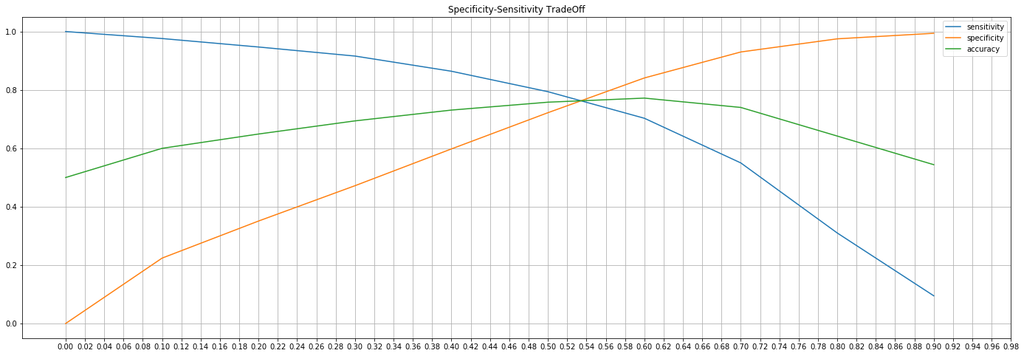

```python
logr_metrics_df.plot(kind='line', figsize=(24,8), grid=True, xticks=np.arange(0,1,0.02),
                title='Specificity-Sensitivity TradeOff');
```

- The optimum probability cutoff for Logistic regression model is 0.53

```python
optimum_cutoff = 0.53
y_train_pred_lr_final = y_train_pred_lr.map(lambda x : 1 if x > optimum_cutoff else 0)
y_test_pred_lr_final = y_test_pred_lr.map(lambda x : 1 if x > optimum_cutoff else 0)

train_matrix = confusion_matrix(y_train_resampled, y_train_pred_lr_final)
print('Confusion Matrix for train:\n', train_matrix)
test_matrix = confusion_matrix(y_test, y_test_pred_lr_final)
print('\nConfusion Matrix for test: \n', test_matrix)
```

```
Confusion Matrix for train:
 [[14531  4656]
 [ 4411 14776]]

Confusion Matrix for test:
 [[6313 1918]
 [ 191  582]]
```

```python
print('Train Performance: \n')
model_metrics(train_matrix)

print('\n\nTest Performance : \n')
model_metrics(test_matrix)
```

```
Train Performance:

Accuracy : 0.764
Sensitivity / True Positive Rate / Recall : 0.77
Specificity / True Negative Rate :  0.757
Precision / Positive Predictive Value : 0.76
F1-score : 0.765


Test Performance :

Accuracy : 0.766
Sensitivity / True Positive Rate / Recall : 0.753
Specificity / True Negative Rate :  0.767
Precision / Positive Predictive Value : 0.233
F1-score : 0.356
```

```python
# ROC_AUC score
print('ROC AUC score for Train : ',round(roc_auc_score(y_train_resampled, y_train_pred_lr),3), '\n' )
print('ROC AUC score for Test : ',round(roc_auc_score(y_test, y_test_pred_lr),3) )
```

```
ROC AUC score for Train :  0.843

ROC AUC score for Test :  0.828
```

## Model 1 : Logistic Regression (Interpretable Model Summary)

```python
lr_summary_html = logr3_fit.summary().tables[1].as_html()
lr_results = pd.read_html(lr_summary_html, header=0, index_col=0)[0]
coef_column = lr_results.columns[0]
print('Most important predictors of Churn , in order of importance and their coefficients are as follows : \n')
lr_results.sort_values(by=coef_column, key=lambda x: abs(x), ascending=False)['coef']
```

```
Most important predictors of Churn , in order of importance and their coefficients are as follows :
```

```
loc_ic_t2f_mou_8   -1.2736
total_rech_num_8   -1.2033
total_rech_num_6    0.6053
monthly_3g_8_0      0.3994
monthly_2g_8_0      0.3666
std_ic_t2f_mou_8   -0.3363
std_og_t2f_mou_8   -0.2474
const              -0.2336
monthly_3g_7_0     -0.2099
std_ic_t2f_mou_7    0.1532
sachet_2g_6_0      -0.1108
sachet_2g_7_0      -0.0987
sachet_2g_8_0       0.0488
sachet_3g_6_0      -0.0399
Name: coef, dtype: float64
```

- The above model could be used as the interpretable model for predicting telecom churn.

## PCA

```python
from sklearn.decomposition import PCA
pca = PCA(random_state = 42)
pca.fit(X_train) # note that pca is fit on original train set instead of resampled train set.
pca.components_
```

```
array([[ 1.64887430e-01,  1.93987506e-01,  1.67239205e-01, ...,
         1.43967238e-06, -1.55704675e-06, -1.88892194e-06],
       [ 6.48591961e-02,  9.55966684e-02,  1.20775174e-01, ...,
        -2.12841595e-06, -1.47944145e-06, -3.90881587e-07],
       [ 2.38415388e-01,  2.73645507e-01,  2.38436263e-01, ...,
        -1.25598531e-06, -4.37900299e-07,  6.19889336e-07],
       ...,
       [ 1.68015588e-06,  1.93600851e-06, -1.82065762e-06, ...,
         4.25473944e-03,  2.56738368e-03,  3.51118176e-03],
       [ 0.00000000e+00, -1.11533905e-16,  1.57807487e-16, ...,
         1.73764144e-15,  6.22907679e-16,  1.45339158e-16],
       [ 0.00000000e+00,  4.98537742e-16, -6.02718139e-16, ...,
         1.27514583e-15,  1.25772226e-15,  3.41773342e-16]])
```

```python
pca.explained_variance_ratio_
```

```
array([2.72067612e-01, 1.62438240e-01, 1.20827535e-01, 1.06070063e-01,
       9.11349433e-02, 4.77504400e-02, 2.63978655e-02, 2.56843982e-02,
       1.91789343e-02, 1.68045932e-02, 1.55523468e-02, 1.31676589e-02,
       1.04552128e-02, 7.72970448e-03, 7.22746863e-03, 6.14494838e-03,
       5.62073089e-03, 5.44579273e-03, 4.59009989e-03, 4.38488162e-03,
       3.46703626e-03, 3.27941490e-03, 2.78099200e-03, 2.13444270e-03,
       2.07542043e-03, 1.89794720e-03, 1.41383936e-03, 1.30240760e-03,
       1.15369576e-03, 1.05262500e-03, 9.64293417e-04, 9.16686049e-04,
       8.84067044e-04, 7.62966236e-04, 6.61794767e-04, 5.69667265e-04,
       5.12585166e-04, 5.04441248e-04, 4.82396680e-04, 4.46889495e-04,
       4.36441254e-04, 4.10389488e-04, 3.51844810e-04, 3.12626195e-04,
       2.51673027e-04, 2.34723896e-04, 1.96950034e-04, 1.71296745e-04,
       1.59882693e-04, 1.48330353e-04, 1.45919483e-04, 1.08583729e-04,
       1.04038518e-04, 8.90621848e-05, 8.53009223e-05, 7.60704088e-05,
       7.57150133e-05, 6.16615717e-05, 6.07777411e-05, 5.70517541e-05,
       5.36161089e-05, 5.28495367e-05, 5.14887086e-05, 4.73768570e-05,
       4.71283394e-05, 4.11523975e-05, 4.10392906e-05, 2.86090257e-05,
       2.19793282e-05, 1.58203581e-05, 1.50969788e-05, 1.42865579e-05,
       1.34537530e-05, 1.33026062e-05, 1.10239870e-05, 8.27539516e-06,
       7.55845974e-06, 6.45372276e-06, 6.22570067e-06, 3.42288900e-06,
       3.20804681e-06, 3.09270863e-06, 2.86608967e-06, 2.44898003e-06,
       2.08230568e-06, 1.85144734e-06, 1.64714248e-06, 1.45630245e-06,
       1.35265729e-06, 1.05472047e-06, 9.89133015e-07, 8.65864423e-07,
       7.45065121e-07, 3.66727807e-07, 6.49277820e-08, 6.13357428e-08,
       4.35995018e-08, 2.28152900e-08, 2.00441141e-08, 1.84235145e-08,
       1.66102335e-08, 1.47870989e-08, 1.23390691e-08, 1.12094165e-08,
       1.09702422e-08, 9.51924270e-09, 8.61596309e-09, 7.38051070e-09,
       7.15370081e-09, 6.29095319e-09, 5.00739371e-09, 4.68791660e-09,
       4.23376173e-09, 4.04558169e-09, 3.75847771e-09, 3.71213838e-09,
       3.32806929e-09, 3.23527525e-09, 3.12734302e-09, 2.82062311e-09,
       2.72602311e-09, 2.66103741e-09, 2.46562734e-09, 2.20243536e-09,
       2.15044476e-09, 1.59498492e-09, 1.47087974e-09, 1.06159357e-09,
       9.33938436e-10, 8.10080735e-10, 8.04656028e-10, 6.12994365e-10,
       4.82074297e-10, 4.02577318e-10, 3.58059984e-10, 3.28374076e-10,
       3.03687605e-10, 7.12091816e-11, 6.13978255e-11, 1.04375208e-33,
       1.04375208e-33])
```

#### Scree Plot

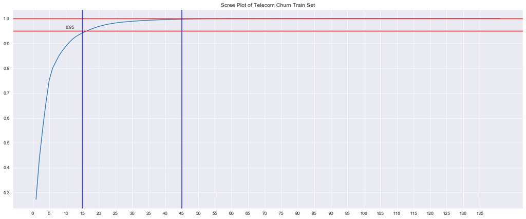

```python
var_cum = np.cumsum(pca.explained_variance_ratio_)
plt.figure(figsize=(20,8))
sns.set_style('darkgrid')
sns.lineplot(np.arange(1,len(var_cum) + 1), var_cum)
plt.xticks(np.arange(0,140,5))
plt.axhline(0.95,color='r')
plt.axhline(1.0,color='r')
plt.axvline(15,color='b')
plt.axvline(45,color='b')
plt.text(10,0.96,'0.95')

plt.title('Scree Plot of Telecom Churn Train Set');
```

```python
# Perform PCA using the first 45 components
pca_final = PCA(n_components=45, random_state=42)
transformed_data = pca_final.fit_transform(X_train)
X_train_pca = pd.DataFrame(transformed_data, columns=["PC_"+str(x) for x in range(1,46)], index = X_train.index)
data_train_pca = pd.concat([X_train_pca, y_train], axis=1)

data_train_pca.head()
```

| mobile_number | PC_1 | PC_2 | PC_3 | PC_4 | PC_5 | PC_6 | PC_7 | PC_8 | PC_9 | PC_10 | PC_11 | PC_12 | PC_13 | PC_14 | PC_15 | PC_16 | PC_17 | PC_18 | PC_19 | PC_20 | PC_21 | PC_22 | PC_23 | PC_24 | PC_25 | PC_26 | PC_27 | PC_28 | PC_29 | … |
| --- | --- | --- | --- | --- | --- | --- | --- | --- | --- | --- | --- | --- | --- | --- | --- | --- | --- | --- | --- | --- | --- | --- | --- | --- | --- | --- | --- | --- | --- | --- |
| 7000166926 | -907.572208 | -342.923676 | 13.094442 | 58.813506 | -95.616159 | -1050.535219 | 254.648987 | -31.445039 | 305.140339 | -216.814250 | 95.825021 | 231.408291 | -111.002572 | -2.007256 | 444.977249 | 31.541681 | 573.831941 | -278.539708 | 30.768637 | -36.915195 | -0.293915 | -83.574447 | -13.960479 | -60.930941 | -53.208613 | 56.049658 | -17.776675 | -12.624526 | 14.149393 | … |
| 7001343085 | 573.898045 | -902.385767 | -424.839214 | -331.153508 | -148.987005 | -36.955710 | -134.445130 | 265.325388 | -92.070929 | -164.203586 | 25.105150 | -36.980621 | 164.785936 | -222.908959 | -12.573878 | -50.569424 | -44.767869 | -62.984835 | -18.100729 | -86.239469 | -115.399141 | -45.776518 | 16.345395 | -21.497140 | -10.541281 | -71.754047 | 29.230830 | -20.880178 | -0.690183 | … |
| 7001863283 | -1538.198366 | 514.032564 | 846.865497 | 57.032319 | -1126.228705 | -84.209511 | -44.422495 | -88.158881 | -58.411887 | 50.518811 | 3.052703 | -229.100202 | -109.215465 | -3.253782 | 7.045279 | -85.645393 | 54.536446 | -52.292779 | 20.978943 | -90.806167 | 96.348659 | 24.280381 | -52.425262 | 42.430049 | -40.627473 | -12.715890 | -4.331719 | -4.092290 | 50.339358 | … |
| 7002275981 | 486.830772 | -224.929803 | 1130.460535 | -496.189015 | 6.009139 | 81.106845 | -148.667431 | 170.280911 | -7.375197 | -99.556793 | -159.659135 | -14.186219 | -98.682096 | 213.233743 | -34.920639 | -17.212430 | 29.644778 | 4.941994 | 2.799763 | -49.580528 | -88.567855 | 16.809461 | -9.471018 | 4.383889 | 29.532189 | 38.211558 | 32.465761 | -5.316497 | -60.149577 | … |
| 7001086221 | -1420.949314 | 794.071749 | 99.221352 | 155.118564 | 145.349456 | 784.723580 | -10.947301 | 609.724272 | -172.482377 | -42.796400 | 59.174124 | -162.912577 | -112.219187 | -55.108445 | 17.303261 | -152.111164 | -611.929832 | 181.577435 | -211.358075 | -77.180329 | 116.282095 | 83.488753 | -26.254488 | 128.490023 | -69.085253 | 4.854304 | -128.278573 | 44.328867 | -6.470515 | … |

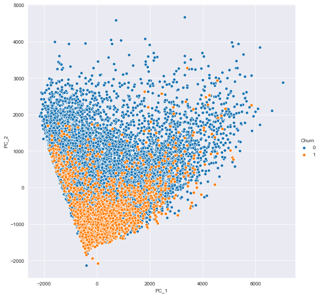

```python
## Plotting principal components
sns.pairplot(data=data_train_pca, x_vars=["PC_1"], y_vars=["PC_2"], hue = "Churn", size=8);
```

## Model 2 : PCA + Logistic Regression Model

```python
# X,y Split
y_train_pca = data_train_pca.pop('Churn')
X_train_pca = data_train_pca

# Transforming test set with pca ( 45 components)
X_test_pca = pca_final.transform(X_test)

# Logistic Regression
lr_pca = LogisticRegression(random_state=100, class_weight='balanced')
lr_pca.fit(X_train_pca,y_train_pca )
```

```
LogisticRegression(class_weight='balanced', random_state=100)
```

```python
# y_train predictions
y_train_pred_lr_pca = lr_pca.predict(X_train_pca)
y_train_pred_lr_pca[:5]
```

```
array([1, 0, 0, 0, 0])
```

```python
# Test Prediction
X_test_pca = pca_final.transform(X_test)
y_test_pred_lr_pca = lr_pca.predict(X_test_pca)
y_test_pred_lr_pca[:5]
```

```
array([1, 1, 1, 1, 1])
```

**Baseline Performance**

```python
train_matrix = confusion_matrix(y_train, y_train_pred_lr_pca)
test_matrix = confusion_matrix(y_test, y_test_pred_lr_pca)

print('Train Performance :\n')
model_metrics(train_matrix)

print('\nTest Performance :\n')
model_metrics(test_matrix)
```

```
Train Performance :

Accuracy : 0.645
Sensitivity / True Positive Rate / Recall : 0.905
Specificity / True Negative Rate :  0.62
Precision / Positive Predictive Value : 0.184
F1-score : 0.306

Test Performance :

Accuracy : 0.086
Sensitivity / True Positive Rate / Recall : 1.0
Specificity / True Negative Rate :  0.0
Precision / Positive Predictive Value : 0.086
F1-score : 0.158
```

#### Hyperparameter Tuning

```python
# Creating a Logistic regression model using pca transformed train set
from sklearn.pipeline import Pipeline
lr_pca = LogisticRegression(random_state=100, class_weight='balanced')
```

```python
from sklearn.model_selection import RandomizedSearchCV, GridSearchCV , StratifiedKFold
params = {
    'penalty' : ['l1','l2','none'],
    'C' : [0,1,2,3,4,5,10,50]
}
folds = StratifiedKFold(n_splits=4, shuffle=True, random_state=100)

search = GridSearchCV(cv=folds, estimator = lr_pca, param_grid=params,scoring='roc_auc', verbose=True, n_jobs=-1)
search.fit(X_train_pca, y_train_pca)
```

```
Fitting 4 folds for each of 24 candidates, totalling 96 fits
```

```
[Parallel(n_jobs=-1)]: Using backend LokyBackend with 4 concurrent workers.
[Parallel(n_jobs=-1)]: Done  42 tasks      | elapsed:    4.0s
[Parallel(n_jobs=-1)]: Done  96 out of  96 | elapsed:    6.9s finished
```

```
GridSearchCV(cv=StratifiedKFold(n_splits=4, random_state=100, shuffle=True),
             estimator=LogisticRegression(class_weight='balanced',
                                          random_state=100),
             n_jobs=-1,
             param_grid={'C': [0, 1, 2, 3, 4, 5, 10, 50],
                         'penalty': ['l1', 'l2', 'none']},
             scoring='roc_auc', verbose=True)
```

```python
# Optimum Hyperparameters
print('Best ROC-AUC score :', search.best_score_)
print('Best Parameters :', search.best_params_)
```

```
Best ROC-AUC score : 0.8763924253372933
Best Parameters : {'C': 0, 'penalty': 'none'}
```

```python
# Modelling using the best LR-PCA estimator
lr_pca_best = search.best_estimator_
lr_pca_best_fit = lr_pca_best.fit(X_train_pca, y_train_pca)

# Prediction on Train set
y_train_pred_lr_pca_best = lr_pca_best_fit.predict(X_train_pca)
y_train_pred_lr_pca_best[:5]
```

```
array([1, 1, 0, 0, 0])
```

```python
# Prediction on test set
y_test_pred_lr_pca_best = lr_pca_best_fit.predict(X_test_pca)
y_test_pred_lr_pca_best[:5]
```

```
array([1, 1, 1, 1, 1])
```

```python
## Model Performance after Hyper Parameter Tuning

train_matrix = confusion_matrix(y_train, y_train_pred_lr_pca_best)
test_matrix = confusion_matrix(y_test, y_test_pred_lr_pca_best)

print('Train Performance :\n')
model_metrics(train_matrix)

print('\nTest Performance :\n')
model_metrics(test_matrix)
```

```
Train Performance :

Accuracy : 0.627
Sensitivity / True Positive Rate / Recall : 0.918
Specificity / True Negative Rate :  0.599
Precision / Positive Predictive Value : 0.179
F1-score : 0.3

Test Performance :

Accuracy : 0.086
Sensitivity / True Positive Rate / Recall : 1.0
Specificity / True Negative Rate :  0.0
Precision / Positive Predictive Value : 0.086
F1-score : 0.158
```

## Model 3 : PCA + Random Forest

```python
from sklearn.ensemble import RandomForestClassifier

# creating a random forest classifier using pca output

pca_rf = RandomForestClassifier(random_state=42, class_weight= {0 : class_1/(class_0 + class_1) , 1 : class_0/(class_0 + class_1) } , oob_score=True, n_jobs=-1,verbose=1)
pca_rf
```

```
RandomForestClassifier(class_weight={0: 0.08640165272733331,
                                     1: 0.9135983472726666},
                       n_jobs=-1, oob_score=True, random_state=42, verbose=1)
```

```python
# Hyper parameter Tuning
params = {
    'n_estimators'  : [30,40,50,100],
    'max_depth' : [3,4,5,6,7],
    'min_samples_leaf' : [15,20,25,30]
}
folds = StratifiedKFold(n_splits=4, shuffle=True, random_state=42)
pca_rf_model_search = GridSearchCV(estimator=pca_rf, param_grid=params,
                                   cv=folds, scoring='roc_auc', verbose=True, n_jobs=-1 )

pca_rf_model_search.fit(X_train_pca, y_train)
```

```
Fitting 4 folds for each of 80 candidates, totalling 320 fits
```

```
[Parallel(n_jobs=-1)]: Using backend LokyBackend with 4 concurrent workers.
[Parallel(n_jobs=-1)]: Done  42 tasks      | elapsed:   23.2s
[Parallel(n_jobs=-1)]: Done 192 tasks      | elapsed:  2.7min
[Parallel(n_jobs=-1)]: Done 320 out of 320 | elapsed:  5.5min finished
[Parallel(n_jobs=-1)]: Using backend ThreadingBackend with 4 concurrent workers.
[Parallel(n_jobs=-1)]: Done  42 tasks      | elapsed:    1.2s
[Parallel(n_jobs=-1)]: Done 100 out of 100 | elapsed:    2.6s finished
```

```
GridSearchCV(cv=StratifiedKFold(n_splits=4, random_state=42, shuffle=True),
             estimator=RandomForestClassifier(class_weight={0: 0.08640165272733331,
                                                            1: 0.9135983472726666},
                                              n_jobs=-1, oob_score=True,
                                              random_state=42, verbose=1),
             n_jobs=-1,
             param_grid={'max_depth': [3, 4, 5, 6, 7],
                         'min_samples_leaf': [15, 20, 25, 30],
                         'n_estimators': [30, 40, 50, 100]},
             scoring='roc_auc', verbose=True)
```

```python
# Optimum Hyperparameters
print('Best ROC-AUC score :', pca_rf_model_search.best_score_)
print('Best Parameters :', pca_rf_model_search.best_params_)
```

```
Best ROC-AUC score : 0.8861621751601011
Best Parameters : {'max_depth': 7, 'min_samples_leaf': 20, 'n_estimators': 100}
```

```python
# Modelling using the best PCA-RandomForest Estimator
pca_rf_best = pca_rf_model_search.best_estimator_
pca_rf_best_fit = pca_rf_best.fit(X_train_pca, y_train)

# Prediction on Train set
y_train_pred_pca_rf_best = pca_rf_best_fit.predict(X_train_pca)
y_train_pred_pca_rf_best[:5]
```

```
[Parallel(n_jobs=-1)]: Using backend ThreadingBackend with 4 concurrent workers.
[Parallel(n_jobs=-1)]: Done  42 tasks      | elapsed:    1.1s
[Parallel(n_jobs=-1)]: Done 100 out of 100 | elapsed:    2.7s finished
[Parallel(n_jobs=4)]: Using backend ThreadingBackend with 4 concurrent workers.
[Parallel(n_jobs=4)]: Done  42 tasks      | elapsed:    0.0s
[Parallel(n_jobs=4)]: Done 100 out of 100 | elapsed:    0.1s finished
```

```
array([0, 0, 0, 0, 0])
```

```python
# Prediction on test set
y_test_pred_pca_rf_best = pca_rf_best_fit.predict(X_test_pca)
y_test_pred_pca_rf_best[:5]
```

```
[Parallel(n_jobs=4)]: Using backend ThreadingBackend with 4 concurrent workers.
[Parallel(n_jobs=4)]: Done  42 tasks      | elapsed:    0.1s
[Parallel(n_jobs=4)]: Done 100 out of 100 | elapsed:    0.1s finished
```

```
array([0, 0, 0, 0, 0])
```

```python
## PCA - RandomForest Model Performance - Hyper Parameter Tuned

train_matrix = confusion_matrix(y_train, y_train_pred_pca_rf_best)
test_matrix = confusion_matrix(y_test, y_test_pred_pca_rf_best)

print('Train Performance :\n')
model_metrics(train_matrix)

print('\nTest Performance :\n')
model_metrics(test_matrix)
```

```
Train Performance :

Accuracy : 0.882
Sensitivity / True Positive Rate / Recall : 0.816
Specificity / True Negative Rate :  0.888
Precision / Positive Predictive Value : 0.408
F1-score : 0.544

Test Performance :

Accuracy : 0.914
Sensitivity / True Positive Rate / Recall : 0.0
Specificity / True Negative Rate :  1.0
Precision / Positive Predictive Value : nan
F1-score : nan
```

```python
## out of bag error
pca_rf_best_fit.oob_score_
```

```
0.8625220164707003
```

## Model 4 : PCA + XGBoost

```python
import xgboost as xgb
pca_xgb = xgb.XGBClassifier(random_state=42, scale_pos_weight= class_0/class_1 ,
                                    tree_method='hist',
                                   objective='binary:logistic',


                                  )  # scale_pos_weight takes care of class imbalance
pca_xgb.fit(X_train_pca, y_train)
```

```
XGBClassifier(base_score=0.5, booster='gbtree', colsample_bylevel=1,
              colsample_bynode=1, colsample_bytree=1, gamma=0, gpu_id=-1,
              importance_type='gain', interaction_constraints='',
              learning_rate=0.300000012, max_delta_step=0, max_depth=6,
              min_child_weight=1, missing=nan, monotone_constraints='()',
              n_estimators=100, n_jobs=0, num_parallel_tree=1, random_state=42,
              reg_alpha=0, reg_lambda=1, scale_pos_weight=10.573852680293097,
              subsample=1, tree_method='hist', validate_parameters=1,
              verbosity=None)
```

```python
print('Baseline Train AUC Score')
roc_auc_score(y_train, pca_xgb.predict_proba(X_train_pca)[:, 1])
```

```
Baseline Train AUC Score
```

```
0.9999996277241286
```

```python
print('Baseline Test AUC Score')
roc_auc_score(y_test, pca_xgb.predict_proba(X_test_pca)[:, 1])
```

```
Baseline Test AUC Score
```

```
0.46093390352284136
```

```python
## Hyper parameter Tuning
parameters = {
              'learning_rate': [0.1, 0.2, 0.3],
              'gamma' : [10,20,50],
              'max_depth': [2,3,4],
              'min_child_weight': [25,50],
              'n_estimators': [150,200,500]}
pca_xgb_search = GridSearchCV(estimator=pca_xgb , param_grid=parameters,scoring='roc_auc', cv=folds, n_jobs=-1, verbose=1)
pca_xgb_search.fit(X_train_pca, y_train)
```

```
Fitting 4 folds for each of 162 candidates, totalling 648 fits
```

```
[Parallel(n_jobs=-1)]: Using backend LokyBackend with 4 concurrent workers.
[Parallel(n_jobs=-1)]: Done  42 tasks      | elapsed:   28.3s
[Parallel(n_jobs=-1)]: Done 192 tasks      | elapsed:  2.1min
[Parallel(n_jobs=-1)]: Done 442 tasks      | elapsed:  4.8min
[Parallel(n_jobs=-1)]: Done 648 out of 648 | elapsed:  8.0min finished
```

```
GridSearchCV(cv=StratifiedKFold(n_splits=4, random_state=42, shuffle=True),
             estimator=XGBClassifier(base_score=0.5, booster='gbtree',
                                     colsample_bylevel=1, colsample_bynode=1,
                                     colsample_bytree=1, gamma=0, gpu_id=-1,
                                     importance_type='gain',
                                     interaction_constraints='',
                                     learning_rate=0.300000012,
                                     max_delta_step=0, max_depth=6,
                                     min_child_weight=1, missing=nan,
                                     monotone_...
                                     n_estimators=100, n_jobs=0,
                                     num_parallel_tree=1, random_state=42,
                                     reg_alpha=0, reg_lambda=1,
                                     scale_pos_weight=10.573852680293097,
                                     subsample=1, tree_method='hist',
                                     validate_parameters=1, verbosity=None),
             n_jobs=-1,
             param_grid={'gamma': [10, 20, 50],
                         'learning_rate': [0.1, 0.2, 0.3],
                         'max_depth': [2, 3, 4], 'min_child_weight': [25, 50],
                         'n_estimators': [150, 200, 500]},
             scoring='roc_auc', verbose=1)
```

```python
# Optimum Hyperparameters
print('Best ROC-AUC score :', pca_xgb_search.best_score_)
print('Best Parameters :', pca_xgb_search.best_params_)
```

```
Best ROC-AUC score : 0.8955777259491308
Best Parameters : {'gamma': 10, 'learning_rate': 0.1, 'max_depth': 2, 'min_child_weight': 50, 'n_estimators': 500}
```

```python
# Modelling using the best PCA-XGBoost Estimator
pca_xgb_best = pca_xgb_search.best_estimator_
pca_xgb_best_fit = pca_xgb_best.fit(X_train_pca, y_train)

# Prediction on Train set
y_train_pred_pca_xgb_best = pca_xgb_best_fit.predict(X_train_pca)
y_train_pred_pca_xgb_best[:5]
```

```
array([0, 0, 0, 0, 0])
```

```python
X_train_pca.head()
```

| mobile_number | PC_1 | PC_2 | PC_3 | PC_4 | PC_5 | PC_6 | PC_7 | PC_8 | PC_9 | PC_10 | PC_11 | PC_12 | PC_13 | PC_14 | PC_15 | PC_16 | PC_17 | PC_18 | PC_19 | PC_20 | PC_21 | PC_22 | PC_23 | PC_24 | PC_25 | PC_26 | PC_27 | PC_28 | PC_29 | … |
| --- | --- | --- | --- | --- | --- | --- | --- | --- | --- | --- | --- | --- | --- | --- | --- | --- | --- | --- | --- | --- | --- | --- | --- | --- | --- | --- | --- | --- | --- | --- |
| 7000166926 | -907.572208 | -342.923676 | 13.094442 | 58.813506 | -95.616159 | -1050.535219 | 254.648987 | -31.445039 | 305.140339 | -216.814250 | 95.825021 | 231.408291 | -111.002572 | -2.007256 | 444.977249 | 31.541681 | 573.831941 | -278.539708 | 30.768637 | -36.915195 | -0.293915 | -83.574447 | -13.960479 | -60.930941 | -53.208613 | 56.049658 | -17.776675 | -12.624526 | 14.149393 | … |
| 7001343085 | 573.898045 | -902.385767 | -424.839214 | -331.153508 | -148.987005 | -36.955710 | -134.445130 | 265.325388 | -92.070929 | -164.203586 | 25.105150 | -36.980621 | 164.785936 | -222.908959 | -12.573878 | -50.569424 | -44.767869 | -62.984835 | -18.100729 | -86.239469 | -115.399141 | -45.776518 | 16.345395 | -21.497140 | -10.541281 | -71.754047 | 29.230830 | -20.880178 | -0.690183 | … |
| 7001863283 | -1538.198366 | 514.032564 | 846.865497 | 57.032319 | -1126.228705 | -84.209511 | -44.422495 | -88.158881 | -58.411887 | 50.518811 | 3.052703 | -229.100202 | -109.215465 | -3.253782 | 7.045279 | -85.645393 | 54.536446 | -52.292779 | 20.978943 | -90.806167 | 96.348659 | 24.280381 | -52.425262 | 42.430049 | -40.627473 | -12.715890 | -4.331719 | -4.092290 | 50.339358 | … |
| 7002275981 | 486.830772 | -224.929803 | 1130.460535 | -496.189015 | 6.009139 | 81.106845 | -148.667431 | 170.280911 | -7.375197 | -99.556793 | -159.659135 | -14.186219 | -98.682096 | 213.233743 | -34.920639 | -17.212430 | 29.644778 | 4.941994 | 2.799763 | -49.580528 | -88.567855 | 16.809461 | -9.471018 | 4.383889 | 29.532189 | 38.211558 | 32.465761 | -5.316497 | -60.149577 | … |
| 7001086221 | -1420.949314 | 794.071749 | 99.221352 | 155.118564 | 145.349456 | 784.723580 | -10.947301 | 609.724272 | -172.482377 | -42.796400 | 59.174124 | -162.912577 | -112.219187 | -55.108445 | 17.303261 | -152.111164 | -611.929832 | 181.577435 | -211.358075 | -77.180329 | 116.282095 | 83.488753 | -26.254488 | 128.490023 | -69.085253 | 4.854304 | -128.278573 | 44.328867 | -6.470515 | … |

```python
# Prediction on test set
X_test_pca = pca_final.transform(X_test)
X_test_pca = pd.DataFrame(X_test_pca, index=X_test.index, columns = X_train_pca.columns)
y_test_pred_pca_xgb_best = pca_xgb_best_fit.predict(X_test_pca)
y_test_pred_pca_xgb_best[:5]
```

```
array([1, 1, 1, 1, 1])
```

```python
## PCA - XGBOOST [Hyper parameter tuned] Model Performance

train_matrix = confusion_matrix(y_train, y_train_pred_pca_xgb_best)
test_matrix = confusion_matrix(y_test, y_test_pred_pca_xgb_best)

print('Train Performance :\n')
model_metrics(train_matrix)

print('\nTest Performance :\n')
model_metrics(test_matrix)
```

```
Train Performance :

Accuracy : 0.873
Sensitivity / True Positive Rate / Recall : 0.887
Specificity / True Negative Rate :  0.872
Precision / Positive Predictive Value : 0.396
F1-score : 0.548

Test Performance :

Accuracy : 0.086
Sensitivity / True Positive Rate / Recall : 1.0
Specificity / True Negative Rate :  0.0
Precision / Positive Predictive Value : 0.086
F1-score : 0.158
```

```python
## PCA - XGBOOST [Hyper parameter tuned] Model Performance
print('Train AUC Score')
print(roc_auc_score(y_train, pca_xgb_best.predict_proba(X_train_pca)[:, 1]))
print('Test AUC Score')
print(roc_auc_score(y_test, pca_xgb_best.predict_proba(X_test_pca)[:, 1]))
```

```
Train AUC Score
0.9442462043611259
Test AUC Score
0.6353301334697982
```

### Recommendations

```python
print('Most Important Predictors of churn , in the order of importance are : ')
lr_results.sort_values(by=coef_column, key=lambda x: abs(x), ascending=False)['coef']
```

```
Most Important Predictors of churn , in the order of importance are :
```

```
loc_ic_t2f_mou_8   -1.2736
total_rech_num_8   -1.2033
total_rech_num_6    0.6053
monthly_3g_8_0      0.3994
monthly_2g_8_0      0.3666
std_ic_t2f_mou_8   -0.3363
std_og_t2f_mou_8   -0.2474
const              -0.2336
monthly_3g_7_0     -0.2099
std_ic_t2f_mou_7    0.1532
sachet_2g_6_0      -0.1108
sachet_2g_7_0      -0.0987
sachet_2g_8_0       0.0488
sachet_3g_6_0      -0.0399
Name: coef, dtype: float64
```

From the above, the following are the strongest indicators of churn

Based on the above indicators the recommendations to the telecom company are :

- Concentrate on users with 1.27 std devations lower than average incoming calls from fixed line. They are most likely to churn.
- Concentrate on users who recharge less number of times ( less than 1.2 std deviations compared to avg) in the 8th month. They are second most likely to churn.
- Models with high sensitivity are the best for predicting churn. Use the PCA + Logistic Regression model to predict churn. It has an ROC score of 0.87, test sensitivity of 100%